# Problem Set 3

Author

### Instructions

#### How to **complete** this assignment.

- Attempt each exercise in order.
- In each code chunk, if you see “# INSERT CODE HERE”, then you are expected to add some code to create the intended output (Make sure to erase “# INSERT CODE HERE” and place your code in its place).
- If my instructions say to “Run the code below…” then you do not need to add any code to the chunk.
- Many exercises may require you to type some text below the code chunk, interpreting the output and answering the questions.
- Please follow the rules from the course syllabus regarding seeking help with this assignment.

#### How to **submit** this assignment.

- When you are finished, click the “Render” button at the top of this panel. If there are no errors, an HTML file should pop up after a few seconds.
- Take a look at the resulting HTML file that pops up. Make sure everything looks correct, your name is listed at the top, and that there is no ‘junk’ code or output.
- Save the HTML file (to your local computer, and/or to a cloud location) as: **Problem Set 3 “Insert Your Name”**.
- Before you upload the file to HuskyCT, you will need to zip/compress the file.
- Upload the problem set zipped/compressed HTML to HuskyCT. **Do not** upload the original .qmd version.
- This assignment is **due Monday, March 10, 2025, no later than 4:00 pm Eastern**. Points will be deducted for late submissions.
- TIP: Start early so that you can troubleshoot any issues with knitting to HTML.

#### Grading Rubric

There are 8 possible points on this assignment.

**Baseline (C level work)**

- Your .qmd file knits to HTML without errors.
- You answer questions correctly but do not use complete sentences.
- There are typos and ‘junk code’ throughout the document.
- You do not put much thought or effort into the Reflection answers.

**Average (B level work)**

- You use complete sentences to answer questions.
- You attempt every exercise/question.

**Advanced (A level work)**

- Your code is simple and concise.
- Unnecessary messages from R are hidden from being displayed in the HTML.
- Your document is typo-free.
- At the discretion of the instructor, you give exceptionally thoughtful or insightful responses.

In this lab, you will work with data from the Quality of Life Explorer created by the UNCC Urban Institute in collaboration with the city of Charlotte, Mecklenburg County, and nearby townships. This dataset describes how various aspects of Charlotte residents’ “quality of life” varies according to neighborhood. You can explore and learn more about this project [here](http://charlottenc.gov/HNS/CE/CommunityInfo/Pages/QOL.aspx).

##### **Exercise 1. (A) Load the appropriate packages and load the data. (1 points)**

```r
library(tidyverse)
qol <- read_csv("qol_PS3.csv")
```

**ANSWER:**

The first section of this lab asks you to explore how adolescent birth rate and income are related at the neighborhood level in Mecklenburg county.

##### **Exercise 2. Visualize the covariation between the rate of adolescent births and median household income. What do you observe about the relationship between these variables? (1 points)**

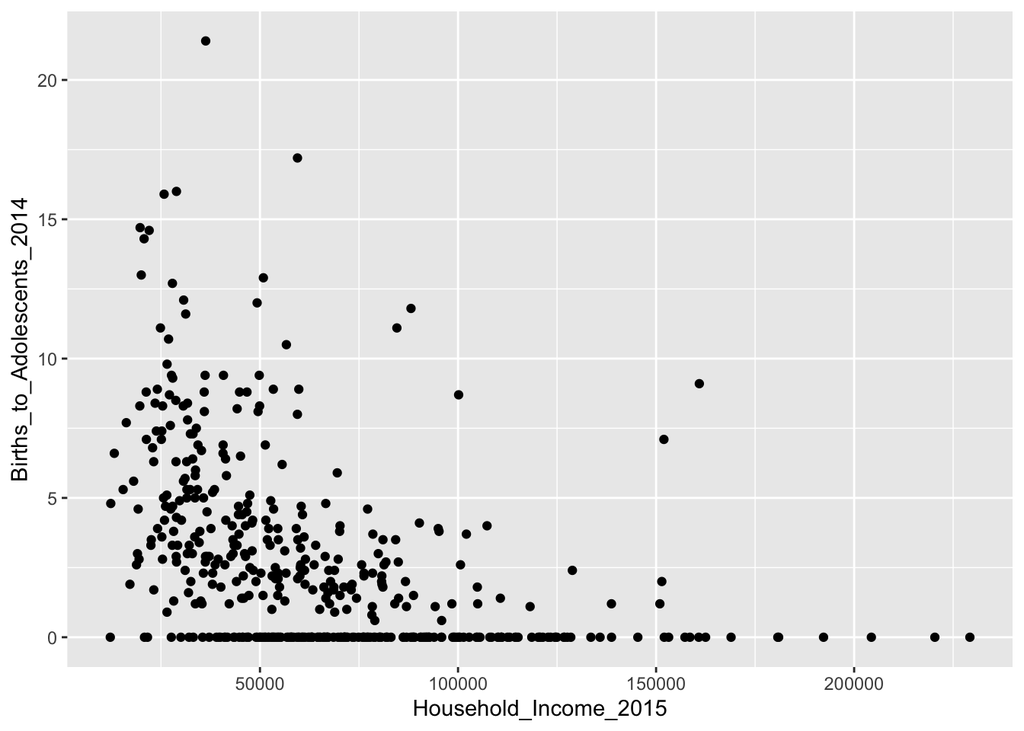

```r
ggplot(qol, aes(x = Household_Income_2015, y = Births_to_Adolescents_2014)) +
  geom_point()
```

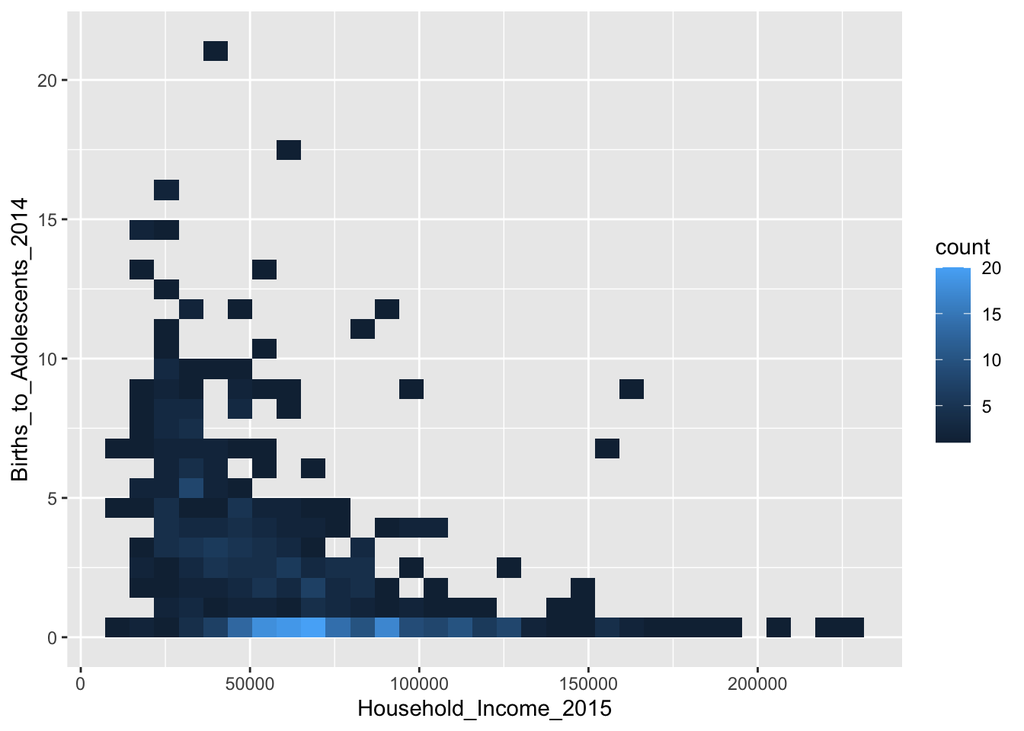

```r
ggplot(qol, aes(x = Household_Income_2015, y = Births_to_Adolescents_2014)) +
  geom_bin2d()
```

##### **Exercise 3. Create a boxplot of the rate of adolescent birth by household income quartile. Use the features of the boxplot (i.e, the bar, box, whiskers and dots) to interpret your findings and discuss the pros and cons of this visualization, including breaking income up by quartile. (1 points)**

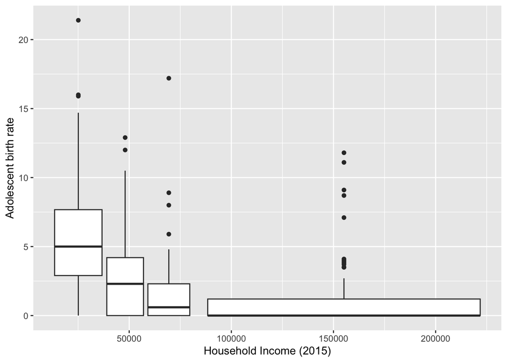

```r
qol %>%
filter(!is.na(Household_Income_2015)) %>%
ggplot(aes(x = Household_Income_2015, y = Births_to_Adolescents_2014)) +
  geom_boxplot(aes(group=cut_number(Household_Income_2015,4))) +
labs(x="Household Income (2015)", y="Adolescent birth rate")
```

##### **Exercise 4. Use the cut_width strategy for “binning” the household income variable. Discuss the pros and cons of this visualization. (1 points)**

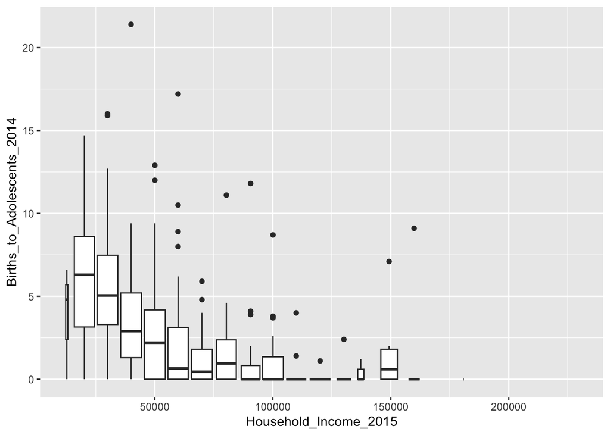

```r
qol %>%
filter(!is.na(Household_Income_2015)) %>%
ggplot(aes(x = Household_Income_2015, y = Births_to_Adolescents_2014)) +
  geom_boxplot(aes(group=cut_width(Household_Income_2015,10000)))
```

##### **Exercise 5. (A) Create a visualization that compares the distributions of the rate of adolescent birth for low-income neighborhoods (with a median HHI of 24257), and high-income neighborhoods (with a median HHI of 48514). (1 points)**